# KNN、區別分析、單純貝氏與支援向量機

一個讓 AI 依固定流程分析資料的 Claude Skill：從資料特性建議方法、經使用者確認後執行，所有數字與圖表由同一支 Python 程式產生，報告附完整程式碼，結果可以重現。

## 什麼情況使用

手上有一份 CSV 或 Excel 資料，想用其他變數**預測**某個結果時：

| 情況 | 例子 |
| --- | --- |
| Y 為類別，想預測觀測值屬於哪一類 | 腫瘤良性或惡性、葡萄品種、客戶是否違約 |
| Y 為連續，關係可能不是直線，想預測數值 | 依車輛規格預測油耗 |
| 特徵多為連續的測量值 | 檢驗數值、化學成分、影像特徵 |
| 特徵數接近或多於樣本數 | 基因表現、光譜 |
| 某一類很少，在意不要漏掉 | 罕見疾病、詐欺 |
| 需要可重現、可交給他人審閱的分析報告 | 諮詢報告、課堂作業、研究附錄 |

不需要先知道方法名稱，以自然語言描述需求即可：

> 請使用 knn-lda-nb-svm-skill 分析附檔 breast_cancer.csv。想用細胞核影像特徵預測腫瘤是良性或惡性，Y 是 diagnosis，正類是 malignant，漏判惡性的代價比誤判高。報告輸出 HTML。

| 不適用 | 原因 |
| --- | --- |
| 解釋各變數的效果、因果推論 | 這些方法以預測為目的，沒有可解釋的係數或檢定 |
| 重複測量、群聚資料 | 觀測值不獨立，交叉驗證會高估表現 |
| 時間序列、存活資料 | 需要專門處理時間與設限的方法 |

## Skill 的組成

```
knn-lda-nb-svm-skill/
├── SKILL.md                 流程、規則與互動方式
├── README.md                安裝、使用方式與限制
├── requirements.txt         Python 套件
├── knn-lda-nb-svm-skill.zip 上傳 Claude 用的壓縮檔
├── references/
│   ├── decision-tree.md     方法建議流程圖、判斷依據與門檻
│   ├── methods.md           各方法的公式、調參與評估指標
│   └── report-spec.md       成果報告規格
├── scripts/
│   └── run_analysis.py      所有計算、圖表與報告檔
├── docs/                    教學文件（中英）
└── examples/                示範資料
```

`SKILL.md` 在 Skill 啟用時載入；其他參考檔依當下步驟讀取，例如建議方法時才讀 `decision-tree.md`，撰寫報告前才讀 `report-spec.md`。

## 方法

### 錯誤率與貝氏分類器

分類的錯誤率是預測錯誤的比例，迴歸則用均方誤差：

$$\frac{1}{n}\sum_{i=1}^{n} I(y_i \ne \hat{y}_i),
\qquad
\frac{1}{n}\sum_{i=1}^{n} \bigl(y_i - \hat{f}(x_i)\bigr)^2$$

使測試錯誤率最小的是**貝氏分類器**：把 $x_0$ 分到條件機率 $\Pr(Y = j \mid X = x_0)$ 最大的類別。實際資料的分佈未知，各方法以不同方式估計這個機率。LDA、QDA 與單純貝氏先描述各類別內 $X$ 的分佈 $f_k(x)$，再以貝氏定理反推：

$$\Pr(Y = k \mid X = x) = \frac{\pi_k f_k(x)}{\sum_{l=1}^{K} \pi_l f_l(x)}$$

$\pi_k$ 是類別 $k$ 的先驗機率，$f_k(x)$ 是類別 $k$ 中 $X$ 的密度。

### KNN

**以離新觀測值最近的 $k$ 個訓練點投票（分類）或取平均（迴歸）。** 用途：分類與迴歸皆可，適合特徵少、樣本多、決策邊界不規則的資料，例如依相似案例預測、手寫數字辨識。

$$\widehat{\Pr}(Y = j \mid X = x_0) = \frac{1}{k} \sum_{i \in \mathcal{N}_k(x_0)} I(y_i = j),
\qquad
\hat{f}(x_0) = \frac{1}{k} \sum_{i \in \mathcal{N}_k(x_0)} y_i$$

|  | KNN 分類 | KNN 迴歸 |
| --- | --- | --- |
| 反應變數 $Y$ | 類別型 | 連續型 |
| 在 $x_0$ 的預測 | $\mathcal{N}_k(x_0)$ 中的多數類別 | $\mathcal{N}_k(x_0)$ 中 $y_i$ 的平均 |
| 估計的目標 | $\Pr(Y = j \mid X = x_0)$ | $E(Y \mid X = x_0)$ |
| scikit-learn | `KNeighborsClassifier` | `KNeighborsRegressor` |

**演算法。**（1）把每個特徵標準化為平均 0、變異數 1；（2）計算 $x_0$ 到每個訓練點的歐氏距離 $d_i = \lVert x_i - x_0 \rVert$；（3）保留最近的 $k$ 個；（4）投票或取平均。

- $k$ 以交叉驗證挑選；兩類問題時用奇數 $k$ 避免平手
- $k$ 小：邊界不規則、變異高；$k$ 大：邊界平滑、偏差高

|  | 適合 KNN | 不適合 KNN |
| --- | --- | --- |
| 目標 | 預測 | 推論：哪些變數重要 |
| 邊界 | 高度不規則 | 接近線性 |
| 樣本數與變數數 | $n$ 遠大於 $p$，$p$ 小 | $p$ 大、無關特徵多 |
| 特徵型態 | 連續型 | 大量類別型 |
| 預測成本 | $n$ 適中 | $n$ 極大且需要即時預測 |

### LDA 與 QDA

**假設各類別內的資料服從多元常態分佈，再以貝氏定理求後驗機率；LDA 假設各類共變異相同而得到線性邊界，QDA 允許各類共變異不同而得到二次邊界。** 用途：只能分類；適合連續特徵、各類形狀大致為橢圓的資料，例如醫學診斷指標、物種分類；LDA 也可把多類資料投影到 $K-1$ 維觀察類別分離。

LDA 假設 $X \mid Y = k \sim N(\mu_k, \Sigma)$，取對數後二次項 $x^\top \Sigma^{-1} x$ 在各類相同而抵銷，得到線性區別函數：

$$\delta_k(x) = x^\top \Sigma^{-1} \mu_k - \tfrac{1}{2} \mu_k^\top \Sigma^{-1} \mu_k + \log \pi_k$$

QDA 假設 $X \mid Y = k \sim N(\mu_k, \Sigma_k)$，二次項不再抵銷：

$$\delta_k(x) = -\tfrac{1}{2} (x - \mu_k)^\top \Sigma_k^{-1} (x - \mu_k) - \tfrac{1}{2} \log \lvert \Sigma_k \rvert + \log \pi_k$$

$x$ 分到 $\delta_k(x)$ 最大的類別。

|  | LDA | QDA |
| --- | --- | --- |
| 邊界 | 線性 | 二次 |
| 共變異參數 | $p(p+1)/2$ | $K\,p(p+1)/2$ |
| 決策規則的參數 | $(K-1)(p+1)$ | $(K-1)\{p(p+3)/2 + 1\}$ |
| 適合 | 各類散佈相近、樣本小到中等 | 各類共變異不同、每類樣本數遠大於 $p$ |
| 限制 | $p$ 接近 $N$ 時不穩定 | 任一類樣本數 $\le p$ 時無法估計 |

兩者都以常態最大概似估計參數，對離群值不穩健。

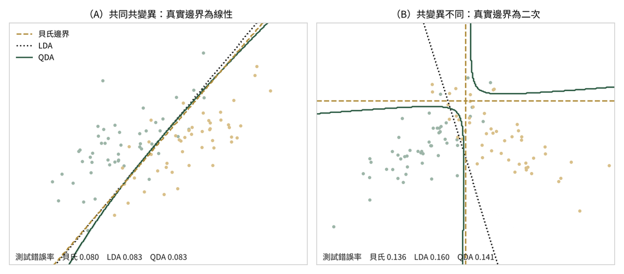

兩類、$p = 2$、每類 50 筆訓練資料。（A）兩類相關係數都是 0.7，真實邊界為線性，LDA 與 QDA 都接近貝氏錯誤率，QDA 多出的彈性沒有帶來好處；（B）相關係數分別為 0.7 與 −0.7，真實邊界為二次，QDA 接近貝氏錯誤率，LDA 的直線代價較高。

**收縮 LDA。** $p$ 接近 $N$ 時，連共同的 $\hat{\Sigma}$ 都不穩定。收縮 LDA 把估計的共變異矩陣往對角矩陣拉近，收縮程度以 Ledoit–Wolf 公式自動決定：

$$\hat{\Sigma}(\lambda) = (1 - \lambda)\,\hat{\Sigma} + \lambda \cdot \frac{\operatorname{tr}(\hat{\Sigma})}{p}\, I$$

```python
LinearDiscriminantAnalysis(solver="lsqr", shrinkage="auto")
```

### 單純貝氏

**假設在每一類之內各特徵彼此獨立，把多維密度拆成一維密度的乘積。** 用途：只能分類；適合特徵很多（文字、基因）、樣本少，或連續與類別特徵混合的資料，例如垃圾郵件分類，也常作為快速的基準模型。

$$f_k(x) = f_{k1}(x_1) \times f_{k2}(x_2) \times \cdots \times f_{kp}(x_p),
\qquad
\Pr(Y = k \mid X = x) = \frac{\pi_k \prod_{j=1}^{p} f_{kj}(x_j)}{\sum_{l=1}^{K} \pi_l \prod_{j=1}^{p} f_{lj}(x_j)}$$

一個 $p$ 維密度變成 $p$ 個一維密度，各自估計，不需要估計共變異。每個一維密度依特徵型態選擇：

| 特徵 | 一維密度 | scikit-learn |
| --- | --- | --- |
| 連續 | 高斯 | `GaussianNB` |
| 類別 | 各水準的比例 | `CategoricalNB` |
| 計數 | 多項分佈 | `MultinomialNB` |

取對數後為加法模型，每個特徵各自貢獻，沒有 $x_j x_l$ 交互作用項：

$$\log\frac{\Pr(Y = k \mid X = x)}{\Pr(Y = K \mid X = x)} = \log\frac{\pi_k}{\pi_K} + \sum_{j=1}^{p} \log\frac{f_{kj}(x_j)}{f_{Kj}(x_j)}$$

若某個類別型特徵的某個水準在第 $k$ 類中從未出現，其估計機率為 0，整個乘積就變成 0。因此在計數上加一個平滑常數（預設 `alpha = 1`，即拉普拉斯平滑）。

| 適合 | 不適合 |
| --- | --- |
| $p$ 很大，甚至 $p > N$ | 特徵高度相關 |
| 每類樣本少 | 交互作用重要 |
| 連續與類別特徵混合 | 需要直接使用機率值 |

### 支援向量機

**找出讓兩類之間間隔最寬的分隔面，只由靠近邊界的支援向量決定，並以核函數處理非線性邊界。** 用途：分類（SVC）與迴歸（SVR）；適合已標準化的連續特徵、中小樣本，或特徵數遠多於樣本數的資料，例如基因表現、影像分類。

軟邊界以鬆弛變數 $\xi_i$ 允許部分點違反邊界，$C$ 是違反邊界的成本：

$$\min_{\beta_0, \beta, \xi}\; \tfrac{1}{2} \lVert \beta \rVert^2 + C \sum_{i=1}^{n} \xi_i
\quad \text{s.t.} \quad y_i(\beta_0 + \beta^\top x_i) \ge 1 - \xi_i,\ \ \xi_i \ge 0$$

- $C$ 小：邊界寬、支援向量多、變異低；$C$ 大：邊界窄、較貼合訓練資料、變異高
- 解只透過內積依賴資料，把內積換成核函數 $K$，就等於在擴大的特徵空間中配適線性邊界，卻不需要計算那個空間：

$$f(x) = \operatorname{sign}\left( \sum_{i \in \mathcal{S}} \alpha_i y_i K(x_i, x) + b \right)$$

| 核函數 | $K(x, x')$ | 參數（scikit-learn） | 適用 |
| --- | --- | --- | --- |
| 線性 | $\langle x, x' \rangle$ | `kernel="linear"` | $p$ 很大 |
| 多項式 | $(1 + \langle x, x' \rangle)^d$ | `kernel="poly", degree=d` | 邊界為低次多項式 |
| 徑向（RBF） | $\exp(-\gamma \lVert x - x' \rVert^2)$ | `kernel="rbf", gamma=γ` | 一般非線性邊界 |

- **調參：** 特徵標準化；$C$、$\gamma$ 在 log₂ 網格上一起以交叉驗證選擇，先粗後細
- **多類別：** 一對一（$K(K-1)/2$ 個分類器，`SVC`）或一對多（$K$ 個分類器，`LinearSVC`）
- **支援向量迴歸：** 預測連續型 Y，使用 ε-不敏感損失，殘差小於 $\varepsilon$ 不計損失，超出部分線性計價，對離群值較不敏感；只有落在 ε 帶邊界上或帶外的點是支援向量

$$V_\varepsilon(r) = \max(0, \lvert r \rvert - \varepsilon)$$

|  | 適合 SVM | 不適合 SVM |
| --- | --- | --- |
| 目標 | 準確的分類 | 需要機率或可解釋的效果 |
| 維度 | $p$ 很大，搭配線性核 | 非線性核搭配大量無關特徵 |
| 樣本數 | 小到中等 | 極大 |
| 類別 | 分得很開 | 嚴重重疊 |

### 比較

**彈性**（flexibility）指模型能配適的函數或決策邊界形狀有多廣。彈性越高，偏差越低、變異越高。資料少、雜訊大時選彈性低的方法；資料多且邊界複雜時才值得用彈性高的方法。

|  | KNN | LDA | QDA | 單純貝氏 | SVM |
| --- | --- | --- | --- | --- | --- |
| 分類 | ✓ | ✓ | ✓ | ✓ | ✓ |
| 迴歸 | ✓ |  |  |  | ✓ |
| 輸出機率 | ✓ | ✓ | ✓ | ✓ |  |
| 邊界 | 任意 | 線性 | 二次 | 加法 | 線性或非線性 |
| 彈性 | 最高 | 最低 | 中到高 | 中 | 由 $C$、$\gamma$ 決定 |
| 需要標準化 | ✓ |  |  |  | ✓ |

## 評估指標

二元分類以混淆矩陣整理預測結果，列為實際類別、欄為預測類別：

|  | 預測為正類 | 預測為負類 |
| --- | --- | --- |
| 實際為正類 | $TP$ | $FN$ |
| 實際為負類 | $FP$ | $TN$ |

| 指標 | 定義 | 意義 |
| --- | --- | --- |
| 準確率 | $(TP + TN)/n$ | 預測正確的比例 |
| 錯誤率 | $(FP + FN)/n$ | 預測錯誤的比例，即 1 − 準確率 |
| 敏感度（召回率） | $TP/(TP + FN)$ | 實際為正類中被抓到的比例 |
| 特異度 | $TN/(TN + FP)$ | 實際為負類中被正確排除的比例 |
| 精確率 | $TP/(TP + FP)$ | 預測為正類中真的是正類的比例 |
| F1 | $2 \cdot \dfrac{\text{精確率} \cdot \text{敏感度}}{\text{精確率} + \text{敏感度}}$ | 精確率與敏感度的調和平均 |
| 平衡準確率 | 各類召回率的平均 | 不受類別比例影響 |
| AUC | ROC 曲線下面積 | 隨機一個正類得分高於隨機一個負類的機率，與門檻無關 |
| RMSE | $\sqrt{\frac{1}{n}\sum (y_i - \hat{y}_i)^2}$ | 迴歸預測誤差的典型大小 |
| MAE | $\frac{1}{n}\sum \lvert y_i - \hat{y}_i \rvert$ | 平均絕對誤差 |
| $R^2$ | $1 - \sum (y_i - \hat{y}_i)^2 / \sum (y_i - \bar{y})^2$ | 相對於以平均數預測，減少的誤差比例 |

- **選模指標：** 最小類別比例 $\ge 20\%$ 用準確率；不平衡時二元用 AUC、多類別用平衡準確率；迴歸用 RMSE
- **比較模型：** 分類為 logistic 迴歸，迴歸為線性迴歸；用來確認非線性或較複雜的方法是否真的帶來改善，不會被選為最終模型
- **準確率的 95% 信賴區間**（Wilson）：

$$\frac{\hat{p} + \frac{z^2}{2n} \pm z\sqrt{\frac{\hat{p}(1-\hat{p})}{n} + \frac{z^2}{4n^2}}}{1 + \frac{z^2}{n}}, \qquad z = 1.96$$

- **兩模型比較：** 同一測試集上以 McNemar 檢定，$H_0$：兩模型錯誤率相同。令 $b$、$c$ 為只有其中一個模型分錯的筆數，在 $H_0$ 下 $b \sim \text{Binomial}(b + c,\ 0.5)$
- **門檻：** 二元分類預設 0.5；稀有類別時依敏感度、精確率與誤判成本調整

## 流程

```
%%{init: {"theme": "base", "themeVariables": {"fontFamily": "Microsoft JhengHei, Noto Sans CJK TC, Noto Sans TC, sans-serif", "fontSize": "15px", "lineColor": "#9A9A9A", "edgeLabelBackground": "#FFFFFF", "primaryTextColor": "#1A1A1A"}, "flowchart": {"curve": "basis", "nodeSpacing": 22, "rankSpacing"…
flowchart TD
 subgraph S1 [" "]
  direction LR
  A([上傳資料]) --> B[資料檢查：型態、缺失、類別編碼]
  B --> C(確認前處理)
  C --> D[EDA 與統計診斷]
 end
 subgraph S2 [" "]
  direction LR
  E{Y 的型態} -- 類別 --> F[分類方法建議]
  E -- 連續 --> G[KNN 迴歸、SVR]
  F --> H(以選單確認候選方法)
  G --> H
 end
 subgraph S3 [" "]
  direction LR
  I[交叉驗證調參] --> J[測試集評估、模型比較]
  J --> K(確認門檻或參數)
  K --> L([報告與完整程式碼])
 end
 S1 --> S2
 S2 --> S3
 class A,B,D,I,J,L proc
 class E dec
 class F,G method
 class C,H,K user
 classDef proc fill:#FFFFFF,stroke:#1A1A1A,color:#1A1A1A
 classDef dec fill:#FFFFFF,stroke:#2F5D46,stroke-width:2px,color:#1A1A1A
 classDef method fill:#EEF4F0,stroke:#2F5D46,color:#1A1A1A
 classDef user fill:#FAF4E4,stroke:#B08D3C,color:#1A1A1A
 style S1 fill:#FFFFFF,stroke:#E6E6E6
 style S2 fill:#FFFFFF,stroke:#E6E6E6
 style S3 fill:#FFFFFF,stroke:#E6E6E6
```

金色為需要使用者確認的步驟。

### 分類方法建議

```
%%{init: {"theme": "base", "themeVariables": {"fontFamily": "Microsoft JhengHei, Noto Sans CJK TC, Noto Sans TC, sans-serif", "fontSize": "15px", "lineColor": "#9A9A9A", "edgeLabelBackground": "#FFFFFF", "primaryTextColor": "#1A1A1A"}, "flowchart": {"curve": "basis", "nodeSpacing": 20, "rankSpacing"…
flowchart TD
 A([Y 為類別]) --> B{特徵型態}
 B -- 文字 --> B1[多項單純貝氏、線性核 SVM]
 B -- 類別型為主 --> B2[單純貝氏]
 B -- 連續型為主 --> C{p 與 n}
 C -- p 接近或大於 n --> C1{特徵高度相關}
 C1 -- 是 --> C2[收縮 LDA、線性核 SVM]
 C1 -- 否 --> C3[收縮 LDA、線性核 SVM、單純貝氏]
 C -- n 遠大於 p --> D{每類樣本數遠大於 p}
 D -- 否 --> D1[LDA、單純貝氏]
 D -- 是 --> E{p 小且 n 遠大於 p}
 E -- 是 --> E1[LDA、QDA、KNN、RBF 核 SVM]
 E -- 否 --> E2[LDA、QDA、RBF 核 SVM]
 class A proc
 class B,C,C1,D,E dec
 class B1,B2,C2,C3,D1,E1,E2 method
 classDef proc fill:#FFFFFF,stroke:#1A1A1A,color:#1A1A1A
 classDef dec fill:#FFFFFF,stroke:#2F5D46,stroke-width:2px,color:#1A1A1A
 classDef method fill:#EEF4F0,stroke:#2F5D46,color:#1A1A1A
```

圖中為建議的方法，在選單中預設勾選；其他可行的方法可加選；無法估計或計算量過大的方法列出原因、不能選。特徵高度相關時，任何分支都不建議單純貝氏。Y 為連續時，$p$ 小且 $n$ 遠大於 $p$ 建議 KNN 迴歸與 SVR，否則建議 SVR。

### 判斷依據與門檻

門檻只用來排除無法估計或計算量過大的方法，其他數值是建議的參考，報告中列出實際數值與門檻。$p$ 為編碼後進入模型的欄位數。

| 判斷 | 依據 | 門檻 |
| --- | --- | --- |
| 類別型為主 | 單純貝氏可直接處理類別特徵 | 類別型特徵 ≥ 一半 |
| $p$ 接近 $n$ | 合併共變異矩陣不穩定，需要收縮 | $n/p < 10$ |
| 特徵高度相關 | 違反單純貝氏的獨立假設，偏差不隨樣本增加而消失 | 最大 $\lvert r \rvert \ge 0.7$ |
| 每類樣本充足 | QDA 需要估計每類的共變異矩陣 | 每折最小類別 $\ge 10p$ |
| KNN 適用 | 特徵多或 $n/p$ 小時距離失去意義 | $p \le 10$ 且 $n/p \ge 20$ |
| QDA 不可行 | 共變異矩陣奇異 | 每折最小類別 $\le p$ |
| LDA 不可行 | 合併共變異矩陣奇異 | $p \ge n$ |
| 核 SVM、SVR 不可行 | 配適時間至少隨 $n^2$ 成長 | 訓練資料 $> 20{,}000$ 筆 |
| 不平衡資料 | 整體正確率無法反映稀有類別 | 最小類別比例 $< 20\%$ |

### 指令

```bash
python scripts/run_analysis.py inspect  --data data.csv --y 目標欄位 --out output
python scripts/run_analysis.py profile  --config config.json
python scripts/run_analysis.py run      --config config.json
python scripts/run_analysis.py finalize --config config.json --report output/report.md
```

| 步驟 | 產出 |
| --- | --- |
| `inspect` | 型態、缺失、Y 的分佈、設定檔範本 |
| `profile` | EDA 圖表、統計診斷、建議方法 |
| `run` | 交叉驗證調參、測試集評估、診斷圖、報告草稿 |
| `finalize` | 檢查解讀已填寫，附完整程式碼與設定，輸出報告 |

每一步之間，AI 向使用者報告並以選單確認，再把決定寫進 `config.json`。

## 分析規範

### 計算

- 所有數值與圖表都由 `run_analysis.py` 實際執行產生；不自行撰寫臨時程式產生數字，也不直接繪製、描述或修改圖表內容
- 需求超出程式能力時先說明限制；經同意擴充程式後，擴充的程式同樣附在報告中
- 程式報錯或環境無法執行時如實告知，不更改資料或方法來繞過錯誤，也不宣稱已完成分析
- 報告中的數字一律取自 `results.json` 或程式產生的表格，不重新計算、不改變位數

### 互動

- 使用繁體中文；統計術語不另外解釋，但每個結果都附諮詢者看得懂的結論
- 需要使用者選擇時以選單呈現，選項附建議與一句理由；**每次只問一個問題**，已提供的資訊不重複詢問
- 可以直接執行檢查與提出建議，但未經同意不得**刪除資料、插補、排除變數、更換方法或擴大參數搜尋**
- 不得把 ID、日期或會洩漏答案的欄位放進 X；未知資訊標示「未提供」，不自行補寫
- 超出適用範圍時說明原因並停止，不自行改用其他方法

### 必須確認與預設

| 必須確認 | 預設（使用者可沿用） |
| --- | --- |
| 資料檔、Y、X、分析目的 | 測試集比例 0.25 |
| 二元分類的正類 | 交叉驗證 5 折，分層並打亂 |
| 數值但不同值 ≤ 5 的欄位是否為類別 | 隨機種子 2026 |
| 數值缺失 ≤ 20%：中位數插補 | 選模指標依類別比例自動決定 |
| 數值缺失 > 20%：列出影響，同意才刪除 | 二元分類門檻 0.5 |
| 類別缺失：眾數或「缺失」類別 | 報告格式 HTML |
| Y 缺失的資料列是否排除（不插補 Y） |  |
| 候選方法 |  |
| 稀有類別時的門檻或類別加權 |  |

### 執行後的檢查

- 最佳參數落在網格邊緣時，向使用者提議擴大網格，同意後重跑
- 稀有類別時，依交叉驗證預測的「不同門檻下的表現」提議門檻，同意後重跑
- 比較用的 logistic 或線性迴歸不低於最終模型時，在報告的結果與限制中說明

## 可重現性

| 設計 | 作用 |
| --- | --- |
| 單一程式 `run_analysis.py` | 所有數字、圖表與報告檔都由它產生 |
| `config.json` | 記錄前處理、刪除的變數與同意內容、候選方法、切分比例、折數、門檻 |
| 固定隨機種子 | 資料切分與交叉驗證的折相同 |
| `Pipeline` | 補值、標準化與編碼只用訓練資料估計，避免資料洩漏 |
| `results.json` | 報告用到的全部數值，交付前與報告比對 |
| 報告附錄 | 完整程式碼、設定、套件版本、資料檔雜湊值與重跑指令 |

同一份資料與設定執行兩次，結果完全相同；任何人拿原始資料執行 `python run_analysis.py run --config config.json`，都能得到報告中的數字與圖。

## 報告

### 章節

| 章節 | 內容 |
| --- | --- |
| 1. 研究問題 | 背景、觀測單位、Y 與 X、分析目的；Y 的各類別意義與正類；未知資訊標示「未提供」 |
| 2. 重點結果與建議 | 3–5 點：最終方法與理由、測試集主要指標與基準比較、最常見的錯誤型態、建議及其前提 |
| 3. 資料與方法 | 樣本與變數；缺失與處理表；前處理；方法選用理由表；資料切分；交叉驗證與參數搜尋 |
| 4. EDA | 描述統計、缺失概況、Y 的分佈、直方圖、依類別分組的箱形圖、散佈圖、相關熱圖 |
| 5. 模型結果與診斷 | 模型比較表、各項指標、混淆矩陣、ROC 曲線、門檻表、各方法的診斷 |
| 6. 限制 | 遺漏變數、樣本代表性、模型假設、測試指標的波動、門檻與誤判成本、插補的影響 |
| 7. 附錄 | 使用方法的公式、完整交叉驗證結果、套件版本、隨機種子、資料雜湊值、重現指令 |
| 8. 完整 Python 程式碼 | 全部程式內容，不得省略 |

### 各方法的診斷

| 方法 | 必附的診斷 |
| --- | --- |
| KNN | 交叉驗證誤差對 $k$ 的曲線，標出選出的 $k$ |
| LDA | 區別座標散佈圖、各區別方向承載的組間變異比例 |
| QDA | 各類共變異結構的比較；$N_k$ 接近 $p$ 時說明估計的不穩定 |
| 單純貝氏 | 使用機率時附校準檢查 |
| SVM | $(C, \gamma)$ 的交叉驗證曲面與最佳點、支援向量個數 |
| SVR、KNN 迴歸 | 預測值對實際值圖、殘差圖；RMSE、MAE、$R^2$ 與基準比較 |

### 寫作規定

- 每個表格、圖與數值之後，附一到三句給諮詢者的解讀，說明它回答了研究問題的哪一部分；例如「敏感度 0.59：實際違約的客戶中，模型抓到約六成，仍有四成會被漏掉」
- 方法選擇與每個結論都寫出依據：樣本數、維度、類別比例、EDA 的觀察或交叉驗證結果
- 方法選用理由以表格列出判斷依據、本資料的數值、依據的規則與對方法選擇的影響
- p 值與信賴區間附結論性解讀：寫出虛無假設、顯著水準與結論；「不顯著」寫成「沒有足夠證據顯示有差異」，不寫成「沒有差異」
- 明確區分訓練、交叉驗證與測試的結果；用於選模的交叉驗證分數不當成獨立的測試表現
- KNN 與 RBF 核 SVM 若要說明變數重要性，只用測試集上的排列重要性，並說明它代表對預測的貢獻
- 離群點只標示與說明，不自動刪除
- 不將關聯或預測表現當成因果證據；未提供誤判成本時，不宣稱模型可直接上線
- 數字格式：比例到小數第一位的百分比，準確率、AUC 等指標到小數第三位，筆數加千分位
- 中文優先標楷體，英文與數字優先 Times New Roman；同一類別在所有圖中使用相同顏色

### 輸出

| 檔案 | 說明 |
| --- | --- |
| `report.html` | 主要報告，圖片內嵌、程式碼可折疊 |
| `report.md` | 同內容，圖片內嵌 |
| `report.qmd` | 可修改後重新 render，需與 `figures/` 放在一起 |
| `report.pdf` | 使用者選擇時才產生 |

## 示範資料

| 檔案 | 任務 | 規模 | Y |
| --- | --- | --- | --- |
| `breast_cancer.csv` | 二元分類 | 569 筆 × 30 個特徵 | `diagnosis` |
| `auto-mpg.csv` | 迴歸 | 398 筆 × 8 個變數 | `mpg` |

## 參考文獻

Bishop, C. M. (2006). *Pattern Recognition and Machine Learning*. Springer.

Chang, C.-C., & Lin, C.-J. (2011). LIBSVM: A library for support vector machines. *ACM Transactions on Intelligent Systems and Technology, 2*(3), 27:1–27:27.

Fisher, R. A. (1936). The use of multiple measurements in taxonomic problems. *Annals of Eugenics, 7*(2), 179–188.

Hastie, T., Tibshirani, R., & Friedman, J. (2009). *The Elements of Statistical Learning* (2nd ed.). Springer.

Hsu, C.-W., Chang, C.-C., & Lin, C.-J. (2003). *A practical guide to support vector classification*. Technical report, National Taiwan University.

James, G., Witten, D., Hastie, T., Tibshirani, R., & Taylor, J. (2023). *An Introduction to Statistical Learning: with Applications in Python*. Springer.

Pedregosa, F., et al. (2011). Scikit-learn: Machine learning in Python. *Journal of Machine Learning Research, 12*, 2825–2830.

Quinlan, R. (1993). *Auto MPG* [Dataset]. UCI Machine Learning Repository. https://doi.org/10.24432/C5859H

Wolberg, W., Mangasarian, O., Street, N., & Street, W. (1993). *Breast Cancer Wisconsin (Diagnostic)* [Dataset]. UCI Machine Learning Repository. https://doi.org/10.24432/C5DW2B